# 201.7. SSObject table

For the Rubin Science Platform at data.lsst.cloud.  
Data Release: [Data Preview 2](https://dp2.lsst.io/)  
Container Size: Large  
LSST Science Pipelines version: r30.0.10  
Last verified to run: 2026-08-05  
Repository: github.com/lsst/tutorial-notebooks  
DOI: 10.11578/rubin/dc.20250909.20

**Learning objective:** To understand the contents of the `SSObject` table and how to access it.

**LSST data products:** `SSObject`

**Packages:** `lsst.rsp`, `lsst.daf.butler`, `lsst.utils.plotting`

**Credit:** Originally developed by the Rubin Community Science team. Please consider acknowledging them if this notebook is used for the preparation of journal articles, software releases, or other notebooks.

**Get Support:** Everyone is encouraged to ask questions or raise issues in the [Support Category](https://community.lsst.org/c/support) of the Rubin Community Forum. Rubin staff will respond to all questions posted there.

## 1. Introduction

- TAP table name: `dp2.SSObject`
- butler table name: `ss_object`
- columns: 80
- rows: 299,343

**Related tutorials:** The TAP and butler data access services are demonstrated in the 100-level "How to" tutorials.

### 1.1. Import packages

Import standard python package `numpy` and `matplotlib`.

From the `lsst` package, import modules for the TAP service, the butler, and plotting.

```python
import numpy as np
import matplotlib.pyplot as plt
from lsst.rsp import RSPDiscovery
from lsst.daf.butler import Butler
from lsst.utils.plotting import (get_multiband_plot_colors,
                                 get_multiband_plot_symbols)
```

### 1.2. Define parameters and functions

Create an instance of the TAP service.

```python
discovery = RSPDiscovery("dp2")
service = discovery.get_tap_client()
```

Create an instance of the Rubin data butler.

```python
butler = Butler("dp2", collections="dp2")
```

Define the colors and symbols to represent the LSST filters in plots.

```python
filter_colors = get_multiband_plot_colors()
filter_names = filter_colors.keys()
filter_symbols = get_multiband_plot_symbols()
```

## 2. Schema (columns)

To browse the table schema visit the [Rubin schema browser](https://sdm-schemas.lsst.io/), or use the TAP service via the Portal Aspect or as demonstrated in Section 2.1.

### 2.1. Retrieve table schema

To retrieve the table schema, define a query for the schema columns of the `SSObject` table and run the query job.

```python
query = "SELECT column_name, datatype, description, unit " \
        "FROM tap_schema.columns " \
        "WHERE table_name = 'dp2.SSObject'"
job = service.submit_job(query)
job.run()
job.wait(phases=['COMPLETED', 'ERROR'])
print('Job phase is', job.phase)
if job.phase == 'ERROR':
    job.raise_if_error()
```

```
Job phase is COMPLETED
```

Retrieve the query results and display them as an `astropy` table with the `to_table()` attribute.

```python
assert job.phase == 'COMPLETED'
results = job.fetch_result().to_table()
results
```

*Table length=80*

| column_name str64 | datatype str64 | description str512 | unit str64 |
| --- | --- | --- | --- |
| r_phaseAngleMin | float | Minimum phase angle observed (r band). | deg |
| r_phaseAngleMax | float | Maximum phase angle observed (r band). | deg |
| ssObjectId | long | Unique identifier. |  |
| designation | char | The unpacked primary provisional designation for this object. |  |
| nObs | int | Total number of LSST observations of this object. |  |
| arc | float | Timespan ("arc") of all LSST observations, t_{last} - t_{first} | d |
| firstObservationMjdTai | double | The time of the first LSST observation of this object (could be precovered), TAI. | d |
| MOIDEarth | float | Minimum orbit intersection distance to Earth. | AU |
| MOIDEarthDeltaV | float | DeltaV at the MOID point. | km/s |
| ... | ... | ... | ... |
| y_H | float | Best fit absolute magnitude (y band). | mag |
| y_HErr | float | Error in the estimate of H (y band). | mag |
| y_G12 | float | Best fit G12 slope parameter (y band). |  |
| y_G12Err | float | Error in the estimate of G12 (y band). |  |
| y_H_y_G12_Cov | float | H–G12 covariance (y band). | mag**2 |
| y_nObsUsed | int | The number of data points used to fit the phase curve (y band). |  |
| y_Chi2 | float | Chi^2 statistic of the phase curve fit (y band). |  |
| y_phaseAngleMin | float | Minimum phase angle observed (y band). | deg |
| y_phaseAngleMax | float | Maximum phase angle observed (y band). | deg |
| y_slope_fit_failed | boolean | G12 fit failed in y band. G12 contains a fiducial value used to fit H. |  |

The table displayed above has been truncated.

Option to print every column name as a list.

```python
# for col in results['column_name']:
#     print(col)
```

Delete the job, but not the `results`.

```python
del query
job.delete()
```

### 2.2. Key columns

The DP2 data release `SSObject` table contains 80 columns. Several of these will be most commonly used.

#### 2.2.1. Solar System Object Id

The long integer that uniquely identifies each Solar System object:

- `ssObjectId`

#### 2.2.2. Number of observations

The number of LSST observations for each Solar System object, including per band quantities:

- `nObs`
- `[band]_nObs`

#### 2.2.3. Earth MOID

The Minimum Orbit Intersection Distance (MOID) to Earth:

- `MOIDEarth`

#### 2.2.4. Tisserand parameter

The Tisserand parameter with respect to Jupiter (T_J):

- `tisserand_J`

#### 2.2.5. Extendedness

The minimum, median, and maximum extendedness values derived from the corresponding `DiaSources`:

- `extendednessMin`
- `extendednessMedian`
- `extendednessMax`

#### 2.2.6. Absolute magnitude

The best fit absolute magnitude `H` per band:

- `[band]_H`

The error in the estimate of `H` per band:

- `[band]_HErr`

#### 2.2.7. Phase curve parameters

The best fit G12 slope parameter per band:

- `[band]_G12`

The error in the estimate of G12 per band:

- `[band]_G12Err`

The Chi^2 statistic of the phase curve fit per band:

- `[band]_Chi2`

The minimum and maximum phase angles observed per band:

- `[band]_phaseAngleMin`
- `[band]_phaseAngleMax`

## 3. Data access

The `SSObject` table is available via the TAP service and the butler.

**Recommended access method:** TAP.

### 3.1. TAP (Table Access Protocol)

The `SSObject` table is stored in Qserv and accessible via the TAP services using ADQL queries.

#### 3.1.1. Catalog size

```python
query = "SELECT COUNT(*) "\
        "FROM dp2.SSObject "
job = service.submit_job(query)
job.run()
job.wait(phases=['COMPLETED', 'ERROR'])
print('Job phase is', job.phase)
if job.phase == 'ERROR':
    job.raise_if_error()
```

```
Job phase is COMPLETED
```

Fetch the results as an `astropy` table.

```python
assert job.phase == 'COMPLETED'
results = job.fetch_result().to_table()
print(results)
```

```
COUNT1
------
299343
```

Clean up.

```python
del query, results
job.delete()
```

#### 3.1.2. Demo query

Define a query to return two of the key columns from Section 2.2 for the top 100 entries in the `SSObject` table.

To query the full `SSObject` table, remove "TOP 100" from the below query.

```python
query = "SELECT TOP 100 ssObjectId, nObs "\
        "FROM dp2.SSObject " \
        "ORDER BY ssObjectId ASC "
job = service.submit_job(query)
job.run()
job.wait(phases=['COMPLETED', 'ERROR'])
print('Job phase is', job.phase)
if job.phase == 'ERROR':
    job.raise_if_error()
```

```
Job phase is COMPLETED
```

Fetch the results as an `astropy` table and convert to a pandas dataframe.

```python
assert job.phase == 'COMPLETED'
results = job.fetch_result()
result_df = results.to_table().to_pandas()
```

Option to display the results.

```python
# result_df
```

Plot a histogram of the number of observations for the TOP 100 Solar System objects in the `SSObject` table.

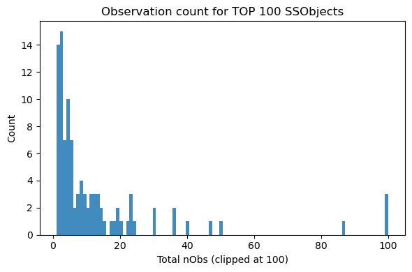

```python
fig, ax = plt.subplots(figsize=(6, 4))
ax.hist(result_df['nObs'].clip(0, 100), bins=100,
        edgecolor='none', alpha=0.85)
ax.set_xlabel('Total nObs (clipped at 100)')
ax.set_ylabel('Count')
ax.set_title('Observation count for TOP 100 SSObjects')
plt.tight_layout()
plt.show()
```

> **Figure 1:** Histograms of the number of observations for the TOP 100 DP2 Solar System objects in the `SSObjects` table.

Clean up.

```python
job.delete()
del query, results, result_df
```

#### 3.1.3. Joinable tables

The `SSObject` table can be joined to the `SSSource` table on the column `ssObjectId`.

The `SSSource` table contains single-epoch solar system source information corresponding to a specific difference image detection.

```python
query = "SELECT TOP 100 sso.ssObjectId, sso.nObs, "\
        "sss.helioRange, sss.topoRange " \
        "FROM dp2.SSObject AS sso " \
        "JOIN dp2.SSSource AS sss ON sso.ssObjectId = sss.ssObjectId"
```

```python
job = service.submit_job(query)
job.run()
job.wait(phases=['COMPLETED', 'ERROR'])
print('Job phase is', job.phase)
if job.phase == 'ERROR':
    job.raise_if_error()
```

```
Job phase is COMPLETED
```

Fetch the results as an `astropy` table and convert to a pandas dataframe.

```python
assert job.phase == 'COMPLETED'
results = job.fetch_result()
result_df = results.to_table().to_pandas()
```

Option to display the results.

```python
# result_df
```

Plot number of observations as a function of heliocentric and topocentric distances for the TOP 100 Solar System object sources.

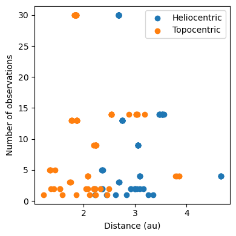

```python
fig, ax = plt.subplots(figsize=(4, 4))

ax.scatter(result_df['helioRange'], result_df['nObs'], label='Heliocentric')
ax.scatter(result_df['topoRange'], result_df['nObs'], label='Topocentric')
plt.xlabel('Distance (au)')
plt.ylabel('Number of observations')
plt.tight_layout()
plt.legend()

plt.show()
```

> **Figure 2:** Number of observations versus heliocentric and topocentric distances for the TOP 100 Solar System object sources.

Clean up.

```python
del query, results, result_df
```

### 3.2. Butler

TAP is the recommended way to access the solar system object table, but the butler can be used to retrieve the same table information.

#### 3.2.1. Demo query

Define the columns to retrieve.

```python
col_list = ['u_H', 'g_H', 'r_H', 'i_H', 'z_H', 'y_H']
```

Get the data from the butler.

```python
results = butler.get('ss_object', parameters={'columns': col_list})
print(len(results))
```

```
299343
```

Option to display the results.

```python
# results
```

Plot histograms of the per-band absolute magnitude ($H$) estimates, marking the median $H$-mag for each band.

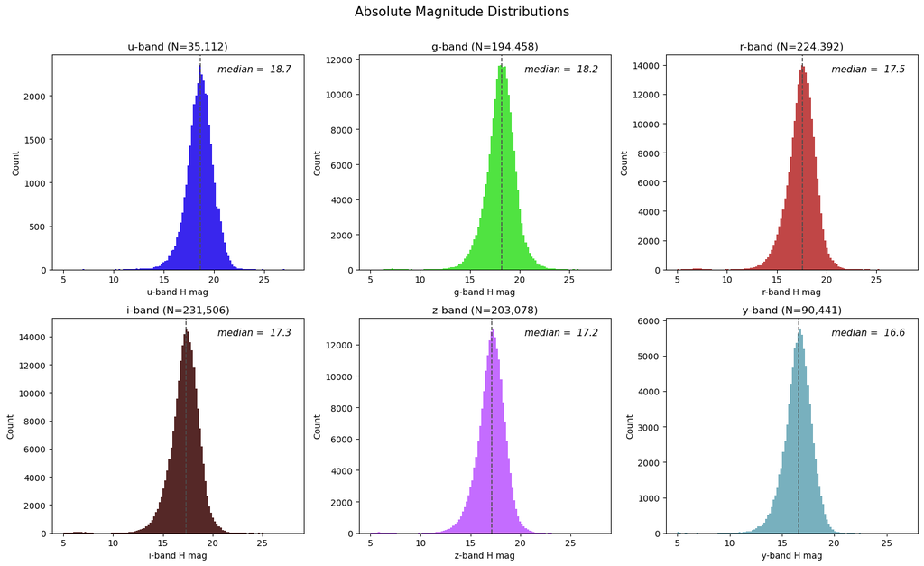

```python
fig, axes = plt.subplots(2, 3, figsize=(15, 9))
for i, b in enumerate(filter_names):
    ax = axes.flat[i]
    unmasked_results = results.filled(0)
    h = unmasked_results[unmasked_results[f'{b}_H'] > 0][f'{b}_H']
    ax.hist(h.clip(5, 28),
            bins=120, color=filter_colors[b],
            alpha=0.85, edgecolor='none')
    ax.set_xlabel(f'{b}-band H mag')
    ax.set_ylabel('Count')
    ax.set_title(f'{b}-band (N={len(h):,})')
    ax.axvline(np.median(h), color='0.3', linestyle='--', lw=1.2)
    ax.text(0.95, 0.92, f'median = {np.median(h): .1f}',
            transform=ax.transAxes, ha='right', fontsize=11,
            fontstyle='italic')
plt.suptitle('Absolute Magnitude Distributions',
             fontsize=15, y=1.01)
plt.tight_layout()
plt.show()
```

Clean up.

```python
del col_list, results
```